# Exposure Consequences - Statistics and Figures

# 1 Overview

This document collects statistics and figures to be used in the manuscript on the exposure consequences project.

## 1.1 Figures

These are the planned figures. Figure one will not be included here, and can in fact simply be re-used from the previous manuscript.

1. Setup & Task (goal: visualize the experiment)
   - A: Setup (side view)
   - B: Rotated training (top view)
   - C: No-cursor reaches (top view)
   - D: Localization (top view)
2. Reach Aftereffects (goal: show motor changes are there, are robust and compare to classic)
   - A: Exposure reach aftereffects (initial & later)
   - B: Classic & Exposure reach aftereffects (initial only? or all?)
3. Localization
   - A: Exposure, active and passive (goal: small/no difference between active and passive)
   - B: Classic, active and passive (goal: larger difference between active and passive, different generalization?)

Maybe:

4. Correlation
   - A: Exposure, active and passive localization predicting reach aftereffects
   - B: Classic, active and passive localization predicting reach aftereffects

## 1.2 Tables

We expand the table used in the previous manuscript to include this paradigm as well.

1. Task order & trial numbers (goal: clarify task order and show similarity between classic and exposure experiment - so probably after Fig 1)

## 1.3 Source scripts

The scripts doing the statistics and figures are in separate R files. They allow many options, but here we will only see / do the ones that we think should go to the manuscript.

First we load those other scripts:

```r
source('shared.R') # functions used everywhere
source('nocursor.R') # functions for no-cursor reach data
source('localization.R') # functions for localization data
source('relateLocalizationNoCursors.R') # functions that correlate the two kinds of data
```

## 1.4 Topics

In the manuscript we’ll first show that there are motor changes after exposure training (with the no-cursor data) and then compare that with the classic. Second is the localization: a) localization shifts after exposure b) the shifts are the same/different from those after classic c) the effects are different across the workspace d) this pattern is indistinguishable / different from that after classic. A third topic might be if localization shifts can predict no-cursor changes, which we’ll call the “correlation” topic. Here we’ll also follow this order:

1. Reach aftereffects
2. Localization
3. Correlations

# 2 Reach Aftereffects

Here is a plot, probably Figure 2:

```
removed 133 outliers, kept 96.6%
removed 133 outliers, kept 96.6%
removed 131 outliers, kept 96.7%
removed 133 outliers, kept 96.6%
```

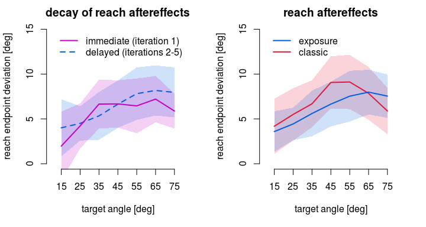

```r
plotReachAftereffects()
```

*For Panel B: Earlier I used the initial block for this plot, but after discussion, we decided to use all data: there’s no significant difference between the initial and other blocks, but using all data allows more accurate estimates.*

Messages of the figure:

- Panel A: there are substantial and persisting reach aftereffects
- Panel B: that are somewhat lower than those in classic (but not that much? but only for some targets?)

These claims require analyses.

## 2.1 Is there an effect of exposure training on reach aftereffects?

First, we show that no-cursor reaches change direction immediately after exposure training (iteration 1):

```r
exposureNoCursorChange()
```

```
removed 133 outliers, kept 96.6%

LME with session and target as fixed effects, and participant as random effect:

Analysis of Deviance Table (Type III tests)

Response: endpoint_angle
                 Chisq Df Pr(>Chisq)
(Intercept)     1.3733  1     0.2413
rotated        74.5681  1     <2e-16 ***
target          8.1406  6     0.2280
rotated:target  7.1149  6     0.3104
---
Signif. codes:  0 ‘***’ 0.001 ‘**’ 0.01 ‘*’ 0.05 ‘.’ 0.1 ‘ ’ 1
```

So this shows that whether or not the feedback was rotated mattered for the reach deviations in the exposure training group, i.e.: there are reach aftereffects.

## 2.2 Do the motor changes persist during localization?

The second analysis is to show that the reach aftereffects aren’t all that different for first and later iterations of the rotated no-cursor tasks. (The baseline is always all aligned iterations of the task.)

```r
exposureAftereffectsPersistent()
```

```
removed 133 outliers, kept 96.6%
removed 133 outliers, kept 96.6%

LME with session and target as fixed effects, and participant as random effect:

Analysis of Deviance Table (Type III tests)

Response: endpoint_angle
                   Chisq Df Pr(>Chisq)
(Intercept)      62.8173  1  2.268e-15 ***
iteration         1.6077  1  0.2048197
target           26.7191  6  0.0001634 ***
iteration:target  3.4796  6  0.7466863
---
Signif. codes:  0 ‘***’ 0.001 ‘**’ 0.01 ‘*’ 0.05 ‘.’ 0.1 ‘ ’ 1
```

So there is no effect of iteration here, which means the reach aftereffects are the same for the first iteration and the average across the other four iterations. We now also have enough power to see an effect of target angle (the generalization curve is not flat), but more importantly the effect of iteration is also not dependent on target.

## 2.3 Are reach aftereffects comparable between classic and exposure training?

Finally, we want to see if there is a difference between the reach aftereffects observed after exposure training and those after classic training.

```r
exposureClassicReachAftereffects()
```

```
removed 133 outliers, kept 96.6%
removed 131 outliers, kept 96.7%

LME with training type and target as fixed effects, and participant as random effect:

Analysis of Deviance Table (Type III tests)

Response: endpoint_angle
                  Chisq Df Pr(>Chisq)
(Intercept)     81.4115  1  < 2.2e-16 ***
training         0.2353  1     0.6276
target          49.4121  6  6.166e-09 ***
training:target  7.6785  6     0.2626
---
Signif. codes:  0 ‘***’ 0.001 ‘**’ 0.01 ‘*’ 0.05 ‘.’ 0.1 ‘ ’ 1
```

I’d have expected there to be some difference between the two training types, perhaps only in interaction with target, but that’s not the case apparently.

The absence of an interaction between training and target could be interpreted to mean that the generalization of reach aftereffects is the same after both kinds of training. Here are the confidence intervals for the peaks of both:

```r
getPeakConfidenceInterval('classic',part='all',CIs=c(.95))
```

```
CLASSIC

removed 131 outliers, kept 96.7%
```

[output not shown]

```
    2.5%      50%    97.5%
41.93610 53.39726 67.09689
```

```r
getPeakConfidenceInterval('exposure',part='all',CIs=c(.95))
```

```
EXPOSURE

removed 133 outliers, kept 96.6%
    2.5%      50%    97.5%
49.23010 62.51653 76.27244
```

Although the two peaks are not different from each other, the 95% confidence interval for the classically trained group includes the 45 degree target (where the visual feedback was during training) but not the 75 degree target, whereas the 95% confidence interval for the exposure training group includes the 75 degree target (where the hand really was during training) but not the 45 degree target. Something might be going on – but the evidence is far from concrete.

To sum up:

1. Rotated exposure training evokes substantial shifts in no-cursor reach direction across the workspace,
2. these changes persist over time, and
3. these changes are comparable to the ones we found after classic training.

# 3 Localization

Here is a plot, probably figure 3:

```
WARNING: Partial localization can not be returned for classic/online data.
```

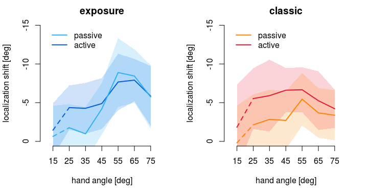

```r
plotLocalization()
```

That looks OK to me. It seems that just like after classic training, there is a change in localization responses following exposure training. There might still be a difference between active and passive localization after exposure training - contrary to our expectations - but it could be smaller than the difference after classic training. This will need to be tested.

## 3.1 Is there a localization shift after exposure training?

We first want to see if there is any overall effect of aligned versus rotated training in the exposure group, with movement type and hand angle as fixed effects, and particiant as random effect.

```r
exposureLocalization(remove15=TRUE)
```

```
LME with session, target and movement type as fixed effects, and participant as random effect:

Analysis of Deviance Table (Type III tests)

Response: taperror_deg
                                     Chisq Df Pr(>Chisq)
(Intercept)                        33.7267  1  6.342e-09 ***
rotated_b                         134.0547  1  < 2.2e-16 ***
passive_b                           0.0684  1  0.7937402
handangle_deg                      17.0418  5  0.0044212 **
rotated_b:passive_b                 0.7516  1  0.3859600
rotated_b:handangle_deg            22.0972  5  0.0005018 ***
passive_b:handangle_deg             7.9422  5  0.1594518
rotated_b:passive_b:handangle_deg   2.9420  5  0.7089216
---
Signif. codes:  0 ‘***’ 0.001 ‘**’ 0.01 ‘*’ 0.05 ‘.’ 0.1 ‘ ’ 1
```

Wether or not the feedback was rotated makes a difference according to two terms in the model. In other words: exposure training caused localization responses to shift (systematically), as we could already guess by looking at the figure.

This means we can look at the difference between repsonses after rotated and after aligned feedback: the training induced shift in localization.

## 3.2 Effects of movement type and hand angle in exposure localization

Let’s first see if there is a difference between active and passive localization after exposure training.

```r
exposureLocalizationShift(remove15=TRUE)
```

```
LME with hand angle and movement type as fixed effects, and participant as random effect:

Analysis of Deviance Table (Type III tests)

Response: taperror_deg
                          Chisq Df Pr(>Chisq)
(Intercept)             24.7154  1  6.645e-07 ***
passive_b                1.1669  1     0.2800
handangle_deg           34.1984  5  2.174e-06 ***
passive_b:handangle_deg  4.5246  5     0.4766
---
Signif. codes:  0 ‘***’ 0.001 ‘**’ 0.01 ‘*’ 0.05 ‘.’ 0.1 ‘ ’ 1
```

There is no difference between passive and active localization after exposure training, even with double the number of trials as in classic delayed.

## 3.3 Comparing localization after exposure and classic training

Let’s see what we get in a model with all data (localization differences between rotated and aligned though) from both groups:

```r
groupLocalization(model='full',remove15=TRUE)
```

```
WARNING: Partial localization can not be returned for classic/online data.


LME with group, hand angle and movement type as fixed effects, and participant as random effect:

Analysis of Deviance Table (Type III tests)

Response: taperror_deg
                                Chisq Df Pr(>Chisq)
(Intercept)                   36.5513  1  1.487e-09 ***
group                          0.3139  1   0.575287
passive_b                      9.6127  1   0.001932 **
handangle_deg                 29.7910  5  1.621e-05 ***
group:passive_b                2.2619  1   0.132595
group:handangle_deg           12.4669  5   0.028921 *
passive_b:handangle_deg        6.4458  5   0.265228
group:passive_b:handangle_deg  1.2769  5   0.937294
---
Signif. codes:  0 ‘***’ 0.001 ‘**’ 0.01 ‘*’ 0.05 ‘.’ 0.1 ‘ ’ 1
```

In the exposure group there is no effect of movement type, but we see one here. This could be because the effect of movement type is much larger in the classic group. This would predict an interaction between group and movement type, but this is not even a trend (p=.133).

What if we don’t care about hand angle:

```r
groupLocalization(model='movementtype',remove15=TRUE)
```

```
WARNING: Partial localization can not be returned for classic/online data.


LME with group and movement type as fixed effects and participant and hand angle as random effects:

Analysis of Deviance Table (Type III tests)

Response: taperror_deg
                  Chisq Df Pr(>Chisq)
(Intercept)     37.0374  1  1.159e-09 ***
group            0.3342  1  0.5632198
passive_b       10.9954  1  0.0009134 ***
group:passive_b  2.7848  1  0.0951644 .
---
Signif. codes:  0 ‘***’ 0.001 ‘**’ 0.01 ‘*’ 0.05 ‘.’ 0.1 ‘ ’ 1
```

Now there is a trend towards significance for the interaction between training group and movement type. That is closer to what we would expect.

Let’s see if the classic group shows an effect of movement type (with the current preprocessing procedures):

```r
classicLocalizationShift(remove15=TRUE)
```

```
WARNING: Partial localization can not be returned for classic/online data.


LME with hand angle and movement type as fixed effects, and participant as random effect:

Analysis of Deviance Table (Type III tests)

Response: taperror_deg
                          Chisq Df Pr(>Chisq)
(Intercept)             13.6221  1  0.0002235 ***
passive_b               11.6351  1  0.0006472 ***
handangle_deg            5.4091  5  0.3680163
passive_b:handangle_deg  3.0120  5  0.6981338
---
Signif. codes:  0 ‘***’ 0.001 ‘**’ 0.01 ‘*’ 0.05 ‘.’ 0.1 ‘ ’ 1
```

So there is a fairly strong effect of movement type in the classic group. Together with the absence of an effect of movement type in the exposure group and a trend of an interaction between group and movement type, this might indicate a sub-threshold effect of movement type in the exposure group in the same direction as the effect of movement type in the classic group.

Also note the absence of an effect of hand angle in the classic group here – potentially because we excluded the 15 degree target.

To sum up our findings on localization:

1. Rotated exposure training leads to changes in localization responses.
2. In the exposure group, there is no effect of movement type: localization responses with and without efference copies are indistinguishable.
3. In the classic group, there is an effect of movement type: localization responses informed by efference copies are shifted more than those with only proprioception (as found before).
4. This predicts an interaction between movement type and group, but that is only a trend, suggesting that either the difference in the classic group is not so large, or that there is a small, sub-threshold difference in the exposure group.
5. The shift in localization is different across the workspace in the exposure group. I.e., there is a generalization *curve*.
6. This effect is not present in the classic group, so that generalization can be said to be flat; there is no *curve*. **NOTE:** When we do include the 15 degree target, there is an effect of hand angle though.

## 3.4 Localization peaks

Decided to add analyses to get the confidence intervals for the peaks of the localization generalization curves:

```r
getPeakLocConfidenceInterval(group='classic',CIs=c(.95), movementtype='active', LRpart='all')
```

```
CLASSIC


WARNING: Partial localization can not be returned for classic/online data.

    2.5%      50%    97.5%
32.20361 48.75740 63.28490
```

```r
getPeakLocConfidenceInterval(group='exposure',CIs=c(.95), movementtype='active', LRpart='all')
```

```
EXPOSURE

    2.5%      50%    97.5%
47.50931 60.40443 75.71908
```

These results mimic those of the reach aftereffects: the median values are different, but they each fall in the other confidence interval. If we want to look at this better, we need to get better estimates of these curves in every participants, by having a wider range of points and more data per point, but probably also larger rotations.

## 3.5 Cumulative Function

Potentially, the wide confidence intervals can be explained by two things: 1) large variation across participants, and 2) incomplete sampling over the function: large swaths of the normal function (not distribution!) are sometimes not sampled at all. Here are some ideas for solutions.

The first problem – large differences between participants – could be dealt with by estimating the function with each participant. This way only conditions within groups can be compared, but that still leaves comparisons between active and passive localization, although comparing reach aftereffects between groups would still not be possible. We can do a Fisher exact test to see if the proportion people with larger shifts in active than in passive localization is higher than 50% in each group. Prediction: should not be different from chance in exposure training, but should be different from chance in classic training.

The second problem – incomplete sampling of the curve – could be dealt with by fitting a cumulative function instead of a normal function. We could assume the training-induced change is 0 at -90 and at 180 degrees, then at every actually estimated point, we take the sum of everything before it, and then scale so that values are between 0 and 1 (divide by the value at 180). (We could also put the extremes at not quite 0, so that at -90 we’re at -1 degrees changes and at 180, we add 1 degree to the last measured point / bin, this should leave some wiggle room for a better fit.) At that point a cumulative function can be fit, and we take the 50% point as the centre of the normal function. I’m not totally sure if this works, but it’s worth a try.

# 4 Correlation

In this section we look at how recalibrated proprioception (hand localization) correlates with reach aftereffects.

*I’m not sure if we should use the initial reach aftereffects here, or the four later blocks. Unfortunately, it does matter for the results, but I don’t want to choose with hindsight.*

This plot shows regression lines with localization shifts as predictor of reach aftereffects:

```
removed 133 outliers, kept 96.6%

WARNING: Partial localization can not be returned for classic/online data.

removed 131 outliers, kept 96.7%
```

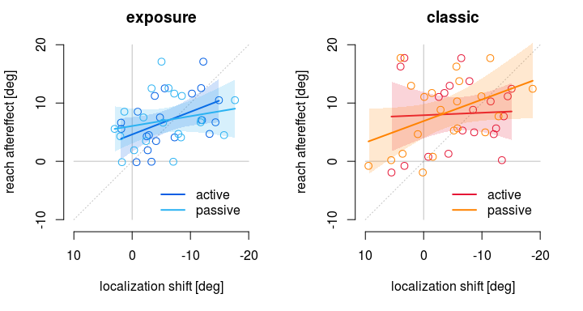

```r
correlations <- correlateNoCursorsLocalization()
```

It looks like for exposure, active localization is the better predictor of reach aftereffects, whereas in classic it is passive localization. But are any of them real? The function also returns the correlation tests and linear regressions for all four datasets.

## 4.1 Pearons Correlations

As one possibility, we can look at the correlations. Not just the p-values, but there are confidence intervals for Pearson’s $\rho$, which allow to directly see if one correlation is stronger/weaker than another:

```r
for (name in names(correlations)) {
  cat(name)
  print(correlations[[name]][['cortest']])
}
```

```
EXPOSURE ACTIVE

    Pearson's product-moment correlation

data:  X and Y
t = -2.2276, df = 18, p-value = 0.03891
alternative hypothesis: true correlation is not equal to 0
95 percent confidence interval:
 -0.75257193 -0.02813027
sample estimates:
       cor
-0.4648643

EXPOSURE PASSIVE

    Pearson's product-moment correlation

data:  X and Y
t = -0.94288, df = 18, p-value = 0.3582
alternative hypothesis: true correlation is not equal to 0
95 percent confidence interval:
 -0.6017021  0.2495297
sample estimates:
       cor
-0.2169468

CLASSIC ACTIVE

    Pearson's product-moment correlation

data:  X and Y
t = -0.19776, df = 19, p-value = 0.8453
alternative hypothesis: true correlation is not equal to 0
95 percent confidence interval:
 -0.4678551  0.3940750
sample estimates:
        cor
-0.04532181

CLASSIC PASSIVE

    Pearson's product-moment correlation

data:  X and Y
t = -1.9954, df = 19, p-value = 0.06054
alternative hypothesis: true correlation is not equal to 0
95 percent confidence interval:
 -0.71877161  0.01883464
sample estimates:
       cor
-0.4162364
```

## 4.2 Linear regression models

And those linear regression models?

[code/results hidden] They get the same p-value, so that seems fine.

## 4.3 Multiple regression models

We’ve decided to use all the no-cursor blocks for these regression and correlations, so perhaps we shouldn’t include the one below where I only use the initial block. The idea behind using only the initial block is that that initial block matches the time the localization is done – relative to the last training.

Here I do step-wise multiple regression, allowing active and passive localization shift as predictor of reach aftereffects. If I do this on all the no-cursor block data, the models converge on using the active localization for the exposure group, and passive localization for the classic group.

If we look at only the initial no-cursor block, the story changes. It uses both active and passive to predict reach aftereffects for the exposure group, but converges on using only an intercept term for the classic group. This might mean that in te classic group there is no relationship between reach aftereffects and localization, or this might mean that in the exposure group we have sufficient amount of measurements to detect the relationship, as we have twice the number of localization trials. One way to rule this out is to use only the first half of the localization data from the exposure group.

Here is what the step-wise multiple regressions look like with all available data:

```r
multipleRegressionLocalization(group='exposure',NCpart='initial')
```

```
removed 133 outliers, kept 96.6%

EXPOSURE

Start:  AIC=50.6
RAE ~ active + passive

          Df Sum of Sq    RSS    AIC
<none>                 185.98 50.598
- passive  1    21.904 207.88 50.825
- active   1   133.743 319.72 59.435

Call:
lm(formula = RAE ~ active + passive, data = df)

Residuals:
    Min      1Q  Median      3Q     Max
-4.8706 -2.9307 -0.3416  2.2677  5.7854

Coefficients:
            Estimate Std. Error t value Pr(>|t|)
(Intercept)   4.2822     1.1639   3.679  0.00186 **
active       -0.6354     0.1817  -3.496  0.00277 **
passive       0.2391     0.1690   1.415  0.17513
---
Signif. codes:  0 ‘***’ 0.001 ‘**’ 0.01 ‘*’ 0.05 ‘.’ 0.1 ‘ ’ 1

Residual standard error: 3.308 on 17 degrees of freedom
Multiple R-squared:  0.4394,    Adjusted R-squared:  0.3735
F-statistic: 6.662 on 2 and 17 DF,  p-value: 0.007303
```

No terms are dropped an the adjusted R squared of the full model is low, but reasonable. *Note that the coefficient for the passive localization is positive.*

For classic training, it looks like this:

```r
multipleRegressionLocalization(group='classic',NCpart='initial')
```

```
WARNING: Partial localization can not be returned for classic/online data.

removed 131 outliers, kept 96.7%

CLASSIC

Start:  AIC=89.64
RAE ~ active + passive

          Df Sum of Sq    RSS    AIC
- active   1    21.735 1148.7 88.039
- passive  1   104.499 1231.4 89.500
<none>                 1126.9 89.637

Step:  AIC=88.04
RAE ~ passive

          Df Sum of Sq    RSS    AIC
- passive  1    83.839 1232.5 87.518
<none>                 1148.7 88.039

Step:  AIC=87.52
RAE ~ 1


Call:
lm(formula = RAE ~ 1, data = df)

Residuals:
     Min       1Q   Median       3Q      Max
-14.6228  -4.8518   0.2389   7.1252  11.8479

Coefficients:
            Estimate Std. Error t value Pr(>|t|)
(Intercept)    9.265      1.713   5.409 2.71e-05 ***
---
Signif. codes:  0 ‘***’ 0.001 ‘**’ 0.01 ‘*’ 0.05 ‘.’ 0.1 ‘ ’ 1

Residual standard error: 7.85 on 20 degrees of freedom
```

The step-wise multiple regression algorithm thinks an intercept-only model is best. Now is this because localization after classic training has little to no information on reach aftereffects, or is this because we have double the data in the exposure group? We can test this partially by throwing away the second half of the data for the exposure group:

```r
# THIS FAILS NOW... maybe because some participants don't have data in the first half?
multipleRegressionLocalization(group='exposure',NCpart='initial', LRpart='first')
```

```
removed these participants:
[1] "BP_2101"
removed 133 outliers, kept 96.6%

EXPOSURE

Start:  AIC=53.88
RAE ~ active + passive

          Df Sum of Sq    RSS    AIC
- passive  1     5.127 241.26 52.288
<none>                 236.14 53.880
- active   1    59.717 295.85 56.163

Step:  AIC=52.29
RAE ~ active

         Df Sum of Sq    RSS    AIC
<none>                241.26 52.288
- active  1    54.614 295.88 54.165

Call:
lm(formula = RAE ~ active, data = df)

Residuals:
    Min      1Q  Median      3Q     Max
-6.6639 -2.3343 -0.4208  3.0299  7.4546

Coefficients:
            Estimate Std. Error t value Pr(>|t|)
(Intercept)   5.5103     1.2107   4.551 0.000283 ***
active       -0.2342     0.1194  -1.962 0.066386 .
---
Signif. codes:  0 ‘***’ 0.001 ‘**’ 0.01 ‘*’ 0.05 ‘.’ 0.1 ‘ ’ 1

Residual standard error: 3.767 on 17 degrees of freedom
Multiple R-squared:  0.1846,    Adjusted R-squared:  0.1366
F-statistic: 3.848 on 1 and 17 DF,  p-value: 0.06639
```

Now the passive localization shifts are thrown out by the algorithm and the active localization shifts don’t contribute much either. This means that perhaps previous papers didn’t find any relationships between recalibrated proprioception and reach aftereffects because not enough data was collected to overcome the noisiness of the measurements?

It also makes me wonder if reach aftereffects in classic can be better predicted by the online localization responses:

```r
multipleRegressionLocalization(group='online',NCpart='initial')
```

```
WARNING: Partial localization can not be returned for classic/online data.

removed 131 outliers, kept 96.7%

ONLINE

Start:  AIC=89.69
RAE ~ active + passive

          Df Sum of Sq    RSS    AIC
- active   1     0.161 1129.8 87.691
- passive  1    88.818 1218.4 89.277
<none>                 1129.6 89.688

Step:  AIC=87.69
RAE ~ passive

          Df Sum of Sq    RSS    AIC
- passive  1    102.72 1232.5 87.518
<none>                 1129.8 87.691

Step:  AIC=87.52
RAE ~ 1


Call:
lm(formula = RAE ~ 1, data = df)

Residuals:
     Min       1Q   Median       3Q      Max
-14.6228  -4.8518   0.2389   7.1252  11.8479

Coefficients:
            Estimate Std. Error t value Pr(>|t|)
(Intercept)    9.265      1.713   5.409 2.71e-05 ***
---
Signif. codes:  0 ‘***’ 0.001 ‘**’ 0.01 ‘*’ 0.05 ‘.’ 0.1 ‘ ’ 1

Residual standard error: 7.85 on 20 degrees of freedom
```

But no.

# 5 Conclusions

What can we conclude? Here is an initial list of what we might conclude.

1. Exposure training leads to robust reach aftereffects that are similar to those after classic training, although they seem to have a more pronouced generalization curve. This means that evoking propceptive recalibration with visual-proprioceptive discrepancies leads to motor changes. In other words: proprioception informs movement plans.
2. Exposure training leads to shifts in localization, that are not very different between active and passive localization. Since both active and passive movements access recalibrated proprioception, while active localization also accesses updated predictions, this indicates that hand localization is makes very good use of proprioception.
   1. Additionally, since predictions should not be updated in exposure training, active localization could have resulted in a *lower* shift in localization if hand location were estimated by combining recalibrated proprioception and updated prediction in a maximum likelihood way. If anything however, active localization is slightly larger (non-significant) than passive localization. This indicates a non-Bayesian process of combining predictions and perceptions – in this case.
   2. After classic training (2016 paper) there was an effect of movement type, which indicates that with a training regime that allows updates of predicted sensory consequences, these updates do indeed also affect hand localization.
   3. Within the workspace however, there is no interaction between movement type and training group (but there is a ‘trend’, p=.09, if hand angle is used as a random effect, in all analyses the 15 degree data is omitted as Denise said). Perhaps there is a small update of predicted proprioceptive consequences, that we can’t parcel out. A more computational approach would be needed to see if this can explain the pattern of results here.
3. Recalibrated proprioception can somewhat predict reach aftereffects, but only after **exposure** training and for *active localization*. This indicates that in some circumstances, recalibrated proprioception might drive motor changes. However, it is possible that the active component of the localization is crucial here. Perhaps exposure training leads to some updates in predicted sensory consequences after all – be they visual or proprioceptive. These would also factor into the reach aftereffects.
   1. There is also a trend towards significance for *passive localization* to predict reach aftereffects after **classic training**. Perhaps active localization is more similar to no-cursor reaches after exposure training, as they both use recalibrated proprioception as well as updated predictions of sensory consequences – which could mostly be proprioceptive consequences after exposure training. This does not explain the trend towards significance for predicting classic reach aftereffects with passive localization. A step-wise multiple regression favours an intercept model for classic reach aftereffects, hence none of the localization data was deemed informative. The same algorithm arrived at a model using active localization to predict exposure reach aftereffects. The intercept model for classic reach aftereffects could signify that not too much should be read into the trend towards significance in the correlation. On the other hand, the exposure group had twice as much data, so that the estimated recalibration would be more reliable within each participant. Perhaps with higher quality estimates of proprioceptive recalibration those would be able to predict part of the reach aftereffects even after classic training.